# Projekt - Szeregi czasowe

## Trend

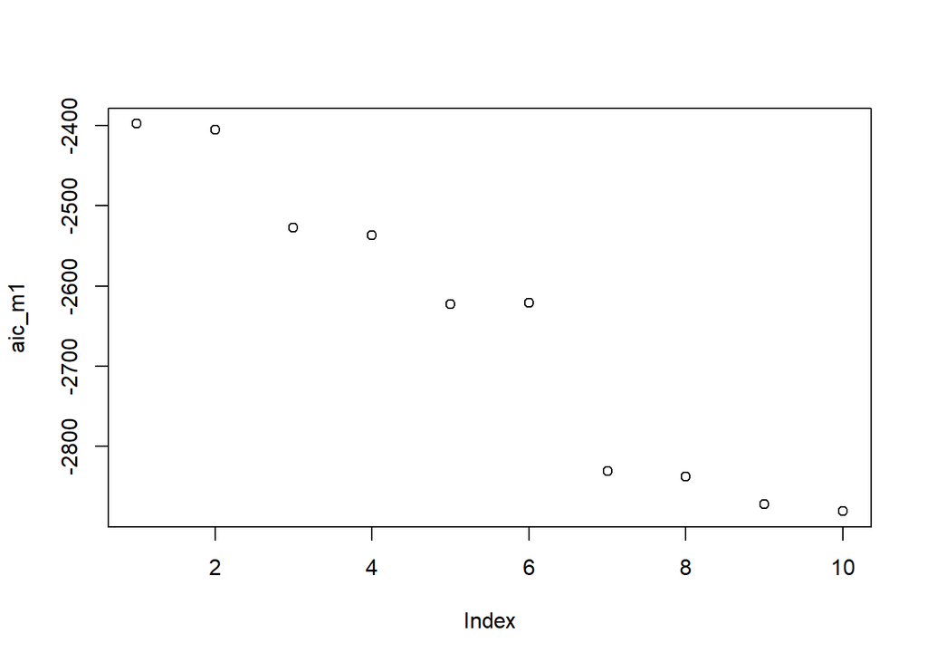

```r
t1 <- 1:length(CNY)
aic_m1 <- AIC(lm(CNY~t1))

for(j in 2:10){
macierz1 <- NULL
for (k in 1:j) {
macierz1 <- cbind(macierz1, t1^k)
}
colnames(macierz1) <- paste0("t^", 1:j)
mod1 <- lm(CNY~macierz1)
aic_m1 <- c(aic_m1, AIC(mod1))
}

plot(aic_m1)
```

Wybieramy wielomian stopnia 7.

```r
t <- 1:length(trend2)

mod71 <- lm(trend2~t + I(t^2) + I(t^3) + I(t^4) + I(t^5)+ I(t^6)+I(t^7))
wsp71 <- coef(mod71)
predict71 <- wsp71[1]+wsp71[2]*t+wsp71[3]*t^2+wsp71[4]*t^3+wsp71[5]*t^4+wsp71[6]*t^5+wsp71[7]*t^6+wsp71[8]*t^7
predict771 <- mod71$fitted.values
max(abs(wsp71[1]+wsp71[2]*t+wsp71[3]*t^2+wsp71[4]*t^3+wsp71[5]*t^4+wsp71[6]*t^5+wsp71[7]*t^6+wsp71[8]*t^6 - mod71$fitted.values))
```

```
## [1] 14.8256
```

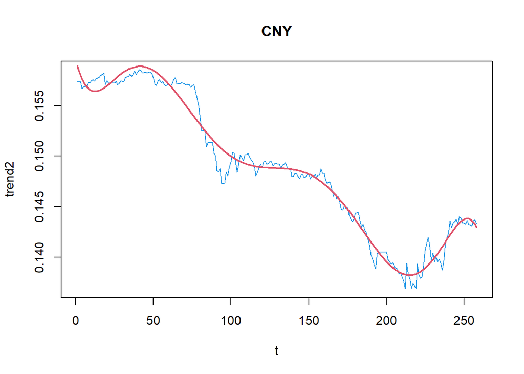

```r
plot(t,trend2, col = 4, main = "CNY", type = "l")
lines(t, predict71, col = 2, lwd = 2)
```

- Test niezależności

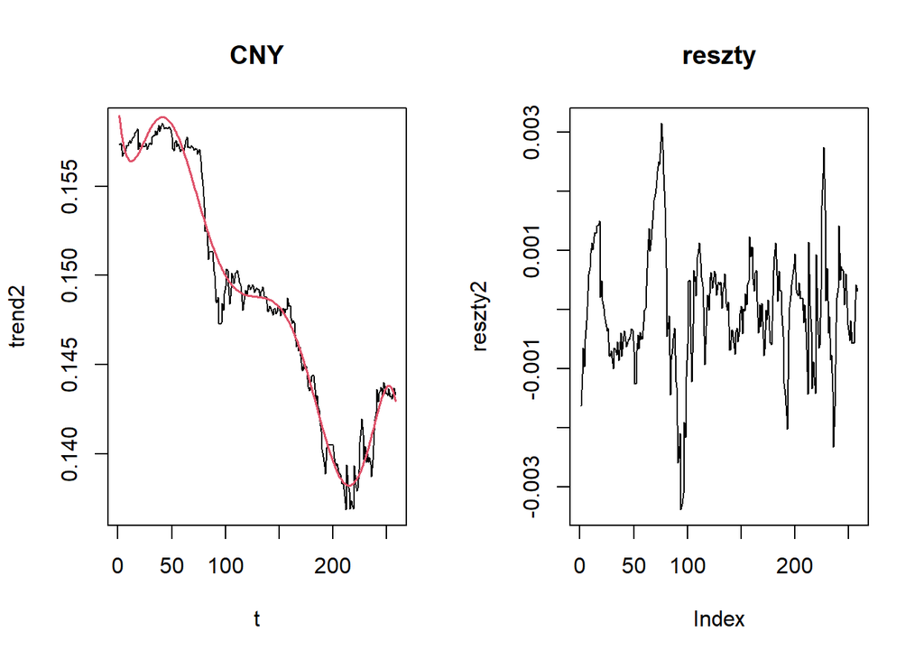

```r
model2 <- lm(trend2~t + I(t^2) + I(t^3) + I(t^4) + I(t^5) + I(t^6) + I(t^7))
reszty2 <- model2$residuals

par(mfrow=c(1,2))
plot(t,trend2, type="l", main="CNY")
lines(t, model2$fitted.values, col=2, lwd=1.5)

plot(reszty2, type="l", main="reszty")
```

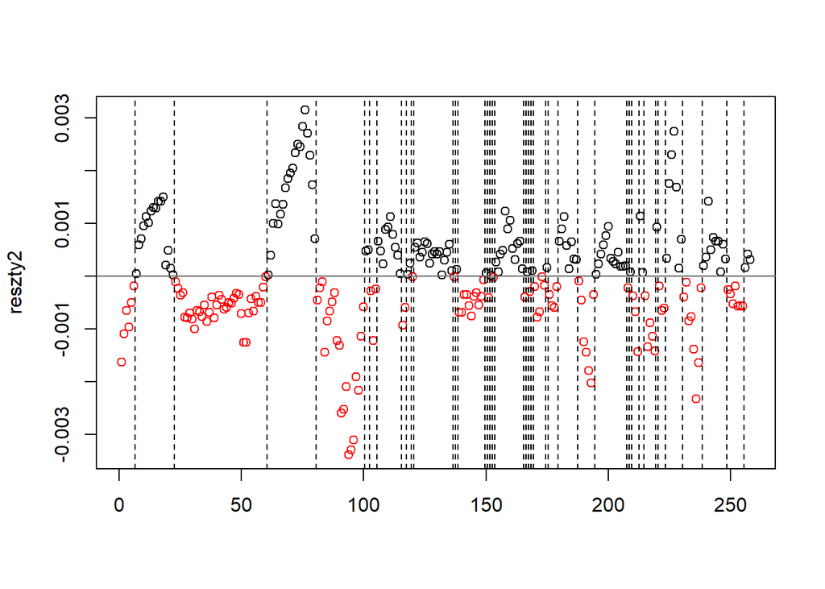

```
##
##  Runs Test
##
## data:  reszty2
## statistic = -10.979, runs = 42, n1 = 129, n2 = 129, n = 258, p-value <
## 2.2e-16
## alternative hypothesis: nonrandomness
```

```r
runs.test(reszty2, alternative = "two.sided", threshold=0, plot=T)
```

```r
Box.test(reszty2, lag=5, type="Ljung")
```

```
##
##  Box-Ljung test
##
## data:  reszty2
## X-squared = 519.22, df = 5, p-value < 2.2e-16
```

```r
Box.test(reszty2, lag=10, type="Ljung")
```

```
##
##  Box-Ljung test
##
## data:  reszty2
## X-squared = 546.14, df = 10, p-value < 2.2e-16
```

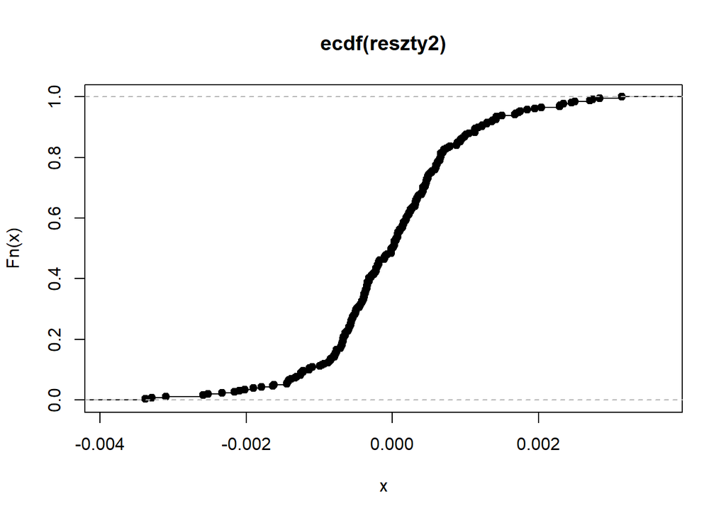

```r
plot(ecdf(reszty2))
```

Odrzucamy hipotezę zerową o tym ,że reszty są niezależne.

- Test normalności reszt

```r
ols_test_normality(reszty2)
```

```
## -----------------------------------------------
##        Test             Statistic       pvalue
## -----------------------------------------------
## Shapiro-Wilk              0.9744          1e-04
## Kolmogorov-Smirnov        0.0762         0.0999
## Cramer-von Mises         85.8314         0.0000
## Anderson-Darling          1.9516          1e-04
## -----------------------------------------------
```

Testy Andersona i Shapiro-Wilka potwierdzają,że odrzucamy hipotezę zerową, czyli nie jest to rozkład normalny. Występuje wewnętrzna zależność.

Test jednorodności wariancji

```r
bptest(model2) #odrzucamy H0
```

```
##
##  studentized Breusch-Pagan test
##
## data:  model2
## BP = 55.884, df = 7, p-value = 9.959e-10
```

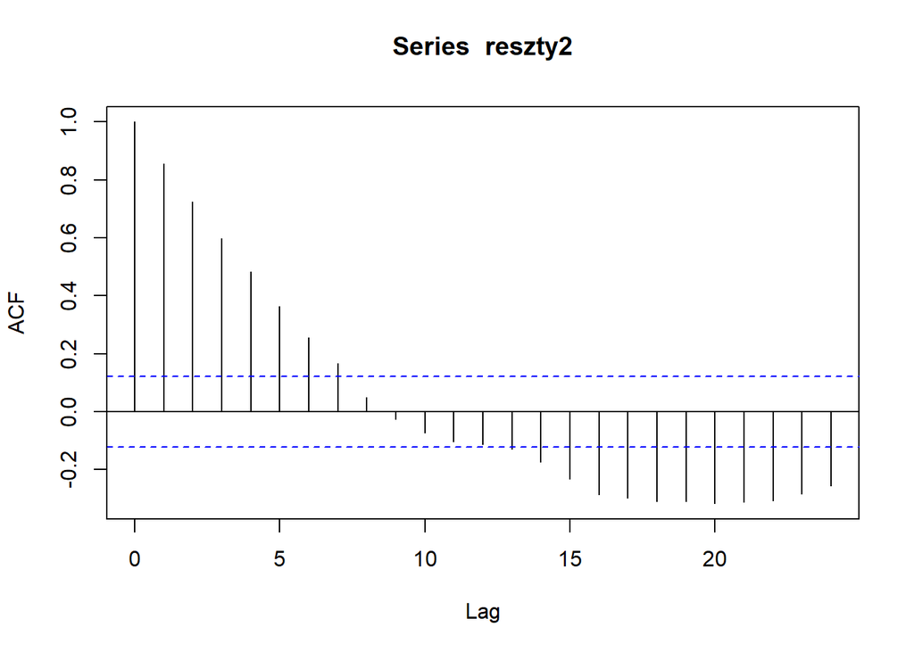

```r
acf(reszty2)
```

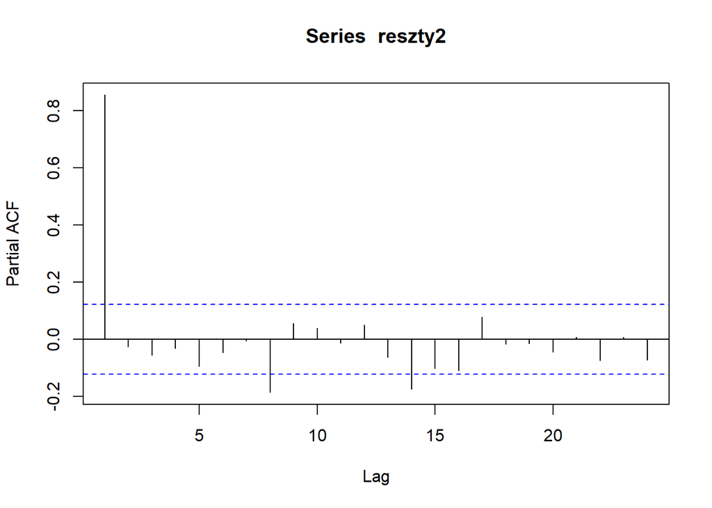

```r
pacf(reszty2)
```

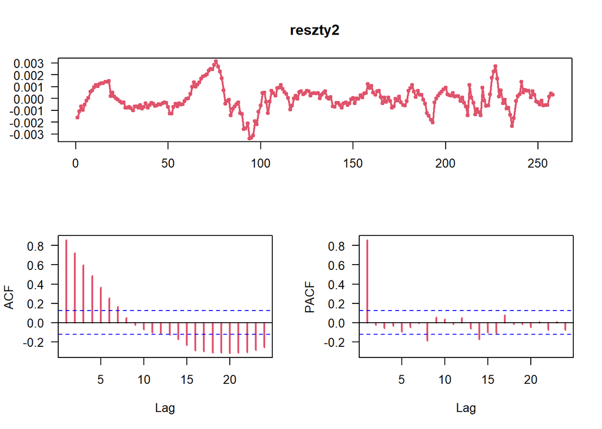

```r
tsdisplay(reszty2, col=2, lwd=2, las=1)
```

Funkcja autokorelacji maleje, występuje trend.

Różnicowanie na resztach:

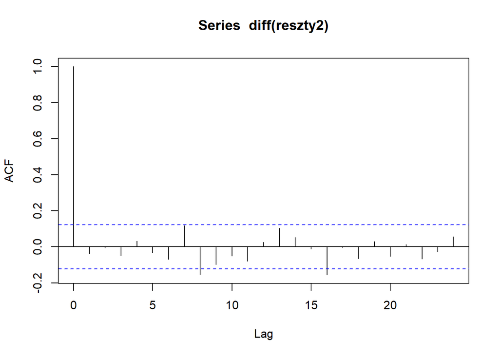

```r
acf(diff(reszty2))
```

## Model ARIMA

```r
arima2 <- auto.arima(diff(reszty2), ic="aic", trace = TRUE, seasonal=F)
```

```
##
##  Fitting models using approximations to speed things up...
##
##  ARIMA(2,0,2) with non-zero mean : Inf
##  ARIMA(0,0,0) with non-zero mean : -3138.84
##  ARIMA(1,0,0) with non-zero mean : -3137.18
##  ARIMA(0,0,1) with non-zero mean : -3137.23
##  ARIMA(0,0,0) with zero mean     : -3140.789
##  ARIMA(1,0,1) with non-zero mean : Inf
##
##  Now re-fitting the best model(s) without approximations...
##
##  ARIMA(0,0,0) with zero mean     : -3140.789
##
##  Best model: ARIMA(0,0,0) with zero mean
```

```r
arima2 <- auto.arima(diff(reszty2))
arima2
```

```
## Series: diff(reszty2)
## ARIMA(0,0,0) with zero mean
##
## sigma^2 = 2.862e-07:  log likelihood = 1571.39
## AIC=-3140.79   AICc=-3140.77   BIC=-3137.24
```

## Stacjonarność szeregu

```r
adf.test(CNY)
```

```
##
##  Augmented Dickey-Fuller Test
##
## data:  CNY
## Dickey-Fuller = -1.4721, Lag order = 6, p-value = 0.7982
## alternative hypothesis: stationary
```

```r
kpss.test(CNY)
```

```
##
##  KPSS Test for Level Stationarity
##
## data:  CNY
## KPSS Level = 4.0701, Truncation lag parameter = 5, p-value = 0.01
```

```r
pp.test(CNY)
```

```
##
##  Phillips-Perron Unit Root Test
##
## data:  CNY
## Dickey-Fuller Z(alpha) = -5.4589, Truncation lag parameter = 5, p-value
## = 0.8041
## alternative hypothesis: stationary
```

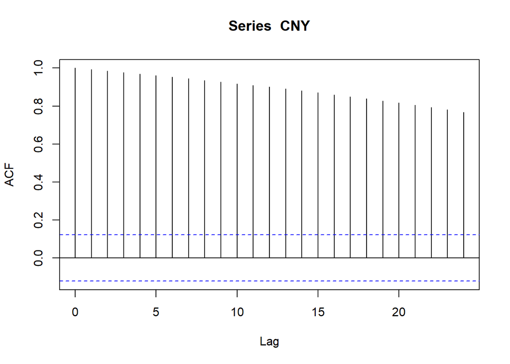

```r
acf(CNY)
```

Nie ma podstaw do odrzucenia hipotezy zerowej. Szereg nie jest stacjonarny.

```r
adf.test(diff(CNY))
```

```
##
##  Augmented Dickey-Fuller Test
##
## data:  diff(CNY)
## Dickey-Fuller = -4.8835, Lag order = 6, p-value = 0.01
## alternative hypothesis: stationary
```

```r
kpss.test(diff(CNY))
```

```
##
##  KPSS Test for Level Stationarity
##
## data:  diff(CNY)
## KPSS Level = 0.16344, Truncation lag parameter = 5, p-value = 0.1
```

```r
pp.test(diff(CNY))
```

```
##
##  Phillips-Perron Unit Root Test
##
## data:  diff(CNY)
## Dickey-Fuller Z(alpha) = -269.78, Truncation lag parameter = 5, p-value
## = 0.01
## alternative hypothesis: stationary
```

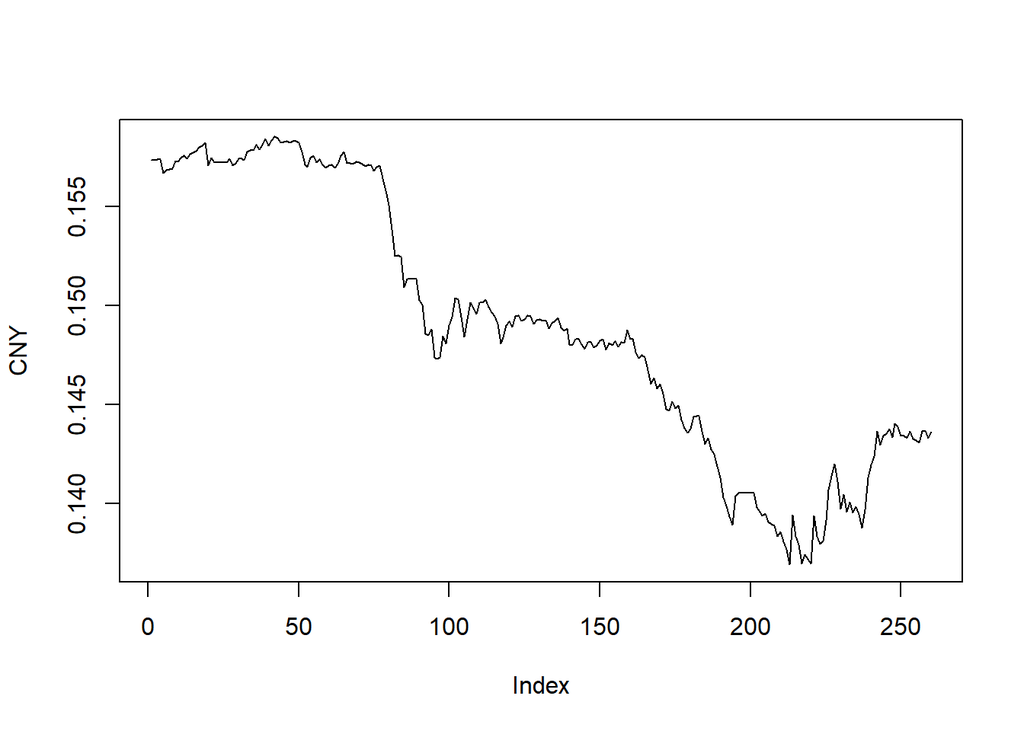

```r
plot(CNY, type = "l")
```

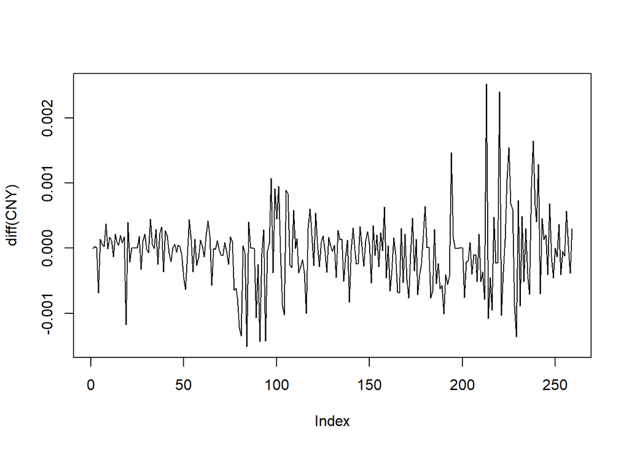

```r
plot(diff(CNY), type = "l")
```

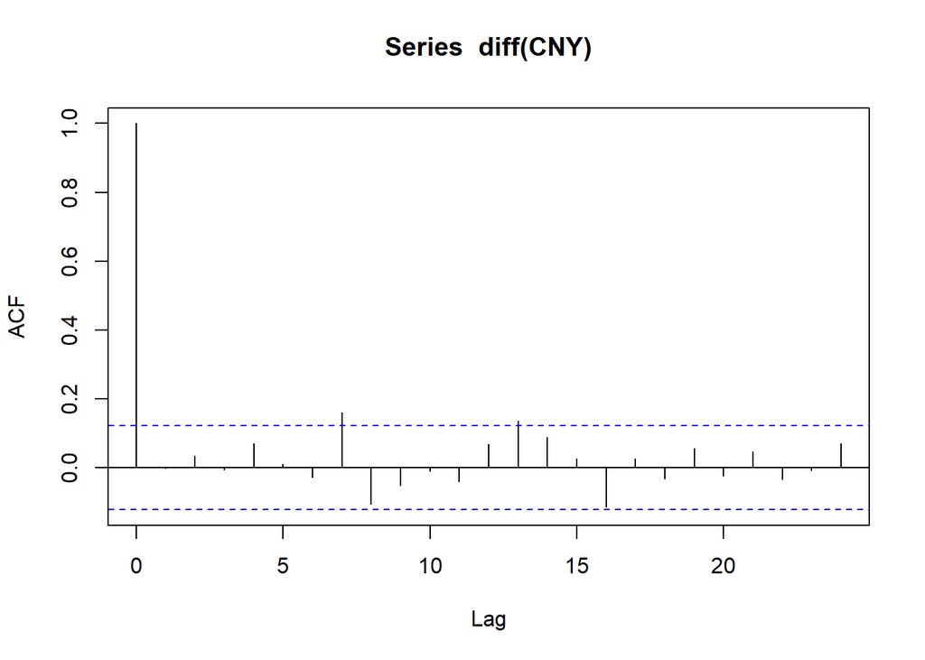

```r
acf(diff(CNY))
```

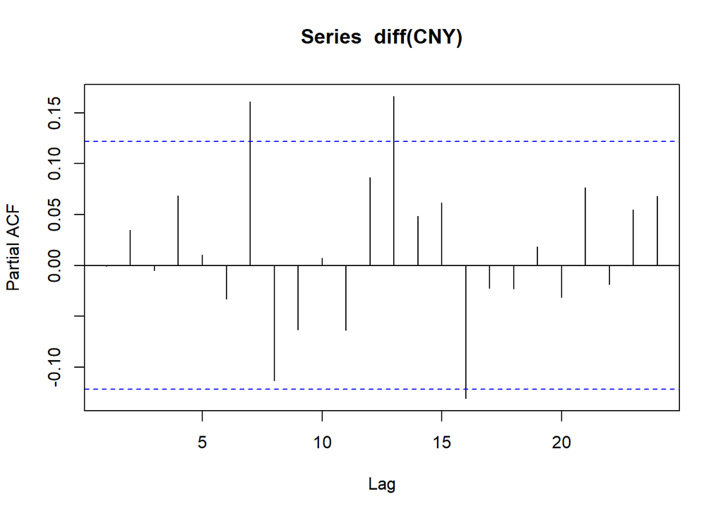

```r
pacf(diff(CNY))
```

Identyfikacja za pomocą klasy ARIMA

```r
auto.arima(diff(CNY), ic="aic", trace = TRUE, seasonal=F)
```

```
##
##  Fitting models using approximations to speed things up...
##
##  ARIMA(2,0,2) with non-zero mean : -3148.002
##  ARIMA(0,0,0) with non-zero mean : -3156.857
##  ARIMA(1,0,0) with non-zero mean : -3153.863
##  ARIMA(0,0,1) with non-zero mean : -3154.857
##  ARIMA(0,0,0) with zero mean     : -3156.382
##  ARIMA(1,0,1) with non-zero mean : Inf
##
##  Now re-fitting the best model(s) without approximations...
##
##  ARIMA(0,0,0) with non-zero mean : -3156.857
##
##  Best model: ARIMA(0,0,0) with non-zero mean
```

```
## Series: diff(CNY)
## ARIMA(0,0,0) with non-zero mean
##
## Coefficients:
##         mean
##       -1e-04
## s.e.   1e-04
##
## sigma^2 = 2.945e-07:  log likelihood = 1580.43
## AIC=-3156.86   AICc=-3156.81   BIC=-3149.74
```

```r
a2 <- auto.arima(diff(CNY))
a2
```

```
## Series: diff(CNY)
## ARIMA(0,0,0) with non-zero mean
##
## Coefficients:
##         mean
##       -1e-04
## s.e.   1e-04
##
## sigma^2 = 2.945e-07:  log likelihood = 1580.43
## AIC=-3156.86   AICc=-3156.81   BIC=-3149.74
```

```r
arima(diff(CNY), order = c(0,0,0))
```

```
##
## Call:
## arima(x = diff(CNY), order = c(0, 0, 0))
##
## Coefficients:
##       intercept
##          -1e-04
## s.e.      1e-04
##
## sigma^2 estimated as 2.933e-07:  log likelihood = 1580.43,  aic = -3156.86
```